# R-for-Beginners-Challenges

## Setup

#### 1. What does the bottom right window (console) of the R studio interface do?

Runs code

#### 2. Why should you set up a .git repository in your project directory?

keep track of changes, backup online

#### 3. IF you don’t specify otherwise, which directory is R studio workingin by default when you open a project

The project directory

## Operators

#### 1. How would you assign the value 467 to the variable kitten?

```r
kitten<-467
kitten=465
467->kitten
```

#### 2. How woud you determine if the variable cat is greater than the variable dog and that cat is less than pony??

```r
cat>dog & cat<pony
```

```
## [1] TRUE
```

```r
(red+blue)<(green-purple)
```

## Using functions

#### 1. How would you find the help file for par: a function that alters graphics parameters?

```r
?par
help(par)
```

#### 2. What is the second argument of the t.test function?

y: an optional (non-empty) numeric vector of data values.

#### 3. What happens if you don’t use the destfile argument in the download.file function?

Error message saying it’s not optional

## Subsetting

### Challenge 1: Fix each of the following common data frame subsetting errors:

#### 1. Extract observations collected for the year 1957

```r
# gapminder[gapminder$year = 1957,]
gapminder[gapminder$year == 1957,]
```

#### 2. Extract all columns except 1 through to 4

```r
# gapminder[,-1:4]
gapminder[,-c(1:4)]
```

#### 3. Extract the rows where the life expectancy is longer the 80 years

```r
# gapminder[gapminder$lifeExp > 80]
gapminder[gapminder$lifeExp > 80,]
```

#### 4. Extract the first row, and the fourth and fifth columns (lifeExp and gdpPercap).

```r
# gapminder[1, 4, 5]
gapminder[1, c(4, 5)]
```

#### 5. Advanced: extract rows that contain information for the years 2002 and 2007

```r
# gapminder[gapminder$year == 2002 | 2007,]
gapminder[gapminder$year == 2002 | gapminder$year == 2007,]
gapminder[gapminder$year %in% c(2002, 2007),]
```

## Plotting

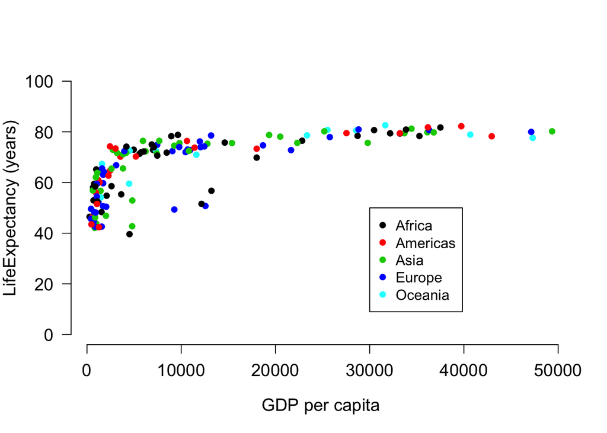

```r
gapminder2007<-subset(gapminder,gapminder$year == 2007)
plot(gapminder2007$gdpPercap, gapminder2007$lifeExp,
     xlab="GDP per capita",        #X axis label
     ylab= "LifeExpectancy (years)",    #Y axis label (somehow get )
     las= 1,                  #Make numbers horizontal on the x axis,
     cex.lab=1.2,             #Increase axis labels font size
     cex.axis=1.2,            #Increase axis label number size
     lwd=2,                   #Increase line/dot thickness
     bty = "n",               #removes black border around the plot
     pch=16,                  #Specifies symbols to draw
     ylim= c(0,100),            #set y axis limits
     col = gapminder$continent) #Set Color based on Continent

legend(x= 30000,                            #x position of legend
       y=50,                                #y position of legend
       legend=levels(gapminder$continent),  #Legend text
       col = c(1:5),
       pch=16)                              #specifies how to draw symbols
```

#### 2. How would you change the data to log axis?

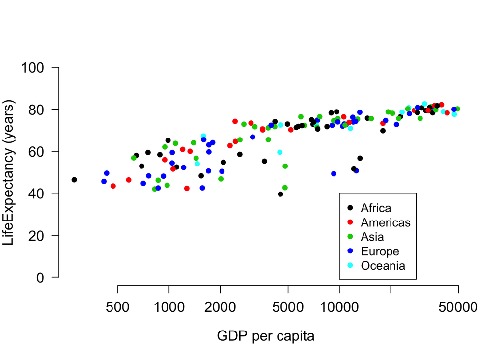

```r
gapminder2007<-subset(gapminder,gapminder$year == 2007)
plot(gapminder2007$gdpPercap, gapminder2007$lifeExp,
     log = "x",
     xlab="GDP per capita",        #X axis label
     ylab= "LifeExpectancy (years)",    #Y axis label (somehow get )
     las= 1,                  #Make numbers horizontal on the x axis,
     cex.lab=1.2,             #Increase axis labels font size
     cex.axis=1.2,            #Increase axis label number size
     lwd=2,                   #Increase line/dot thickness
     bty = "n",               #removes black border around the plot
     pch=16,                  #Specifies symbols to draw
     ylim= c(0,100),            #set y axis limits
     col = gapminder$continent) #Set Color based on Continent

legend(x= 10000,                            #x position of legend
       y=40,                                #y position of legend
       legend=levels(gapminder$continent),  #Legend text
       col = c(1:5),
       pch=16)                              #specifies how to draw symbols
```

#### 3. How would you make a similar plot from European countries, and colorize by year?

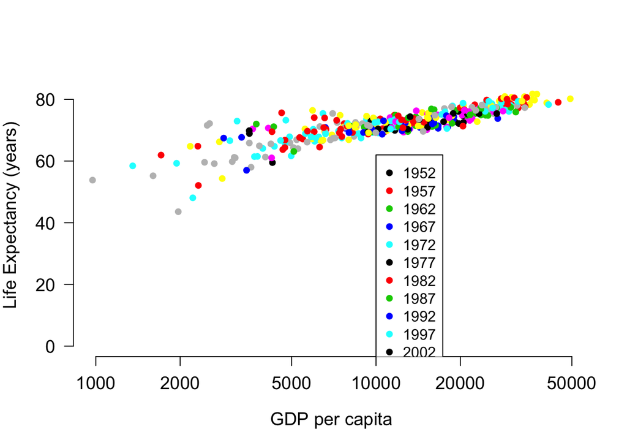

```r
gapminderEu<-subset(gapminder,gapminder$continent == "Europe")
plot(gapminderEu$gdpPercap, gapminderEu$lifeExp,
     log = "x",
     xlab="GDP per capita",        #X axis label
     ylab= "Life Expectancy (years)",    #Y axis label (somehow get )
     las= 1,                  #Make numbers horizontal on the x axis,
     cex.lab=1.2,             #Increase axis labels font size
     cex.axis=1.2,            #Increase axis label number size
     lwd=2,                   #Increase line/dot thickness
     bty = "n",               #removes black border around the plot
     pch=16,                  #Specifies symbols to draw
     ylim= c(0,85),            #set y axis limits
     col = gapminder$year) #Set Color based on Continent

legend(x= 10000,                            #x position of legend
       y=62,                                #y position of legend
       legend=levels(as.factor(gapminder$year)),  #Legend text
       col = c(1:5),
       pch=16)                              #specifies how to draw symbols
```

[figure not shown]

```r
hist(x=gapminder$pop,    #plots life expectancy for all countries in all years
     main="Histogram of population in 2007", #main title
     xlab="Population",                        #x axis label
     ylab="Frequency",                                 #y axis label
     col="red")                                       #color
```